# De-sparsifying patient mutations by smoothing over gene interaction networks

Luca Giudice,Shraddha Pai

2020-07-28

#### Package

netDx 1.1.4

# 1 TL;DR

# 2 Introduction

In this example, we classify Testicular Germ Cell Tumors (TGCT) by pathologic stage of the tumor. We first reduce sparsity by using prior knowledge of a gene interaction network. Conceptually, the logic is that if a patient has a mutation in a given gene, the mutation indirectly impacts interacting genes. The indirect mutation is inferred by label propagation over a gene-gene interaction network. The resulting smoothed network is then used for downstream applications. Hofree et al. showed that indirect mutations inferred by such smoothing improved patient clustering in 4 types of cancer.

This workflow is identical to that of using unsmoothed somatic mutations (see vignette 3); the only difference is an additional step to smooth binary mutations.

# 3 Setup

```r
set.seed(8)
suppressWarnings(suppressMessages(require(netDx)))
suppressWarnings(suppressMessages(require(MultiAssayExperiment)))
```

# 4 Data

Both the patient mutation profiles and the associated pathologic stage of their tumor are downloaded from TCGA with the curatedTCGAData R package. Mutations are represented as a binary matrix with rows corresponding to genes and columns to patients; entry [`i`,`j`] is set to one if gene `i` has a somatic mutation at gene level SNV detected with the algorithm MutSig2CV, while zero otherwise.

```r
genoFile <- paste(path.package("netDx"),"extdata",
                  "TGCT_mutSmooth_geno.txt",
    sep=getFileSep())
geno <- read.delim(genoFile,sep="\t",header=TRUE,as.is=TRUE)

phenoFile <- paste(path.package("netDx"),"extdata",
                   "TGCT_mutSmooth_pheno.txt",
                   sep=getFileSep())
pheno <- read.delim(phenoFile,sep="\t",header=TRUE,as.is=TRUE)
rownames(pheno) <- pheno$ID

table(pheno$STATUS)
```

```
##
## EARLY  LATE
##    66    14
```

# 5 Smooth mutations over a gene interaction network

Load the gene-gene interaction network, downloaded from the NBS python implementation of Huang JK and Ideker T doi:10.1093/bioinformatics/bty186: This network is a compact cancer reference network (CRN) that contains only high-confidence interactions specific to cancer. Huang JK et al. showed that the CRN effectively clusters tumor samples of patients distinguishing them by tumor type and time of survival.

```r
netFile <- paste(path.package("netDx"),"extdata",
                 "CancerNets.txt",
    sep=getFileSep())
cancerNets <- read.delim(netFile,sep="\t",header=T,as.is=T)
head(cancerNets[,1:5])
```

```
##        HSPA2 RPN1 GK2 HSPA6 PPP3R1
## HSPA2      0    1   1     1      1
## RPN1       1    0   0     1      0
## GK2        1    0   0     1      0
## HSPA6      1    1   1     0      1
## PPP3R1     1    0   0     1      0
## DLG1       1    0   0     1      0
```

Use `smoothMutations_LabelProp()` to run label propagation over the mutation matrix, thereby smoothing it. The result of using this strategy on a patient?s binary somatic mutation profile is a non-sparse network-smoothed profile in which the state of each gene is a continuous value which reflects its network proximity to the original mutations.

```r
require(doParallel)
# Start the node clusters for parallel propagation
prop_net <- smoothMutations_LabelProp(geno,cancerNets,numCores=1L)
```

Finally, binarize the smoothed matrix. Only the genes which got a high propagation value are set to one, the others are set to zero. This step ensures that genes which got a low propagation value are not used. More a gene is distant from the original mutations, more its propagation value is low and more is considered unreliable and not involved from them.

```r
genoP <- thresholdSmoothedMutations(
   prop_net,geno,"TGCT_CancerNets",c(20)
   )
```

# 6 Create pathway-level features with binary patient similarity

Smoothed mutations are now grouped at the level of biological pathways. As with other examples, pathways are downloaded from a compilation of curated pathway databases (`.gmt` format). Thereafter, we define pathway-level patient similarity to be binary; i.e. if two patients share a mutation in genes from the same pathway, their mutual similarity is one; else it is zero.

For more details on the individual steps below, see the first vignette related to building a binary predictor.

```r
#Setup to build the predictor
pathwayList <- readPathways(
   fetchPathwayDefinitions("January",2018)
   )
```

```
## Fetching http://download.baderlab.org/EM_Genesets/January_01_2018/Human/symbol/Human_AllPathways_January_01_2018_symbol.gmt
```

```
## File: 8a7bf001ba9_Human_AllPathways_January_01_2018_symbol.gmt
```

```
## Read 3028 pathways in total, internal list has 3009 entries
```

```
##  FILTER: sets with num genes in [10, 200]
```

```
##    => 971 pathways excluded
##    => 2038 left
```

```r
exprdat <- SummarizedExperiment(genoP, colData=pheno)
objList <- list(genetic=exprdat)
```

Now we define functions for patient similarity:

```r
makeNets <- function(dataList,groupList,netDir,numCores,...) {
  netList <- c(); netList2 <- c()

  # create genetic nets
  if (!is.null(groupList[["genetic"]])) {
    netList <- makeMutNets(dataList[["genetic"]],
        groupList[["genetic"]],
        netDir,numC=numCores)
  }
  return(netList)
}

# g geno matrix, genes by patients (columns) - binary
# pList list of genesets
# outDir - dir where nets are to be written
makeMutNets <- function(g,pList,oDir,numC) {
  g <- t(g) # transpose to have genes as columns
  cl    <- makeCluster(numC)
  registerDoParallel(cl)

  numPat <- c()
  netList <- foreach(k=1:length(pList)) %do% {
    idx <- which(colnames(g) %in% pList[[k]])

    if (length(idx)>0) {
      has_mut <- rowSums(g[,idx,drop=FALSE])
      has_mutp <- names(has_mut)[which(has_mut>0)]

      if (length(has_mutp)>=6) {
        ##cat(sprintf("%s: %i patients\n", names(pList)[k],
        ##            length(has_mutp)))
        #numPat <- c(numPat, length(has_mutp))
        pat_pairs <- t(combinat::combn(has_mutp,2));
        pat_pairs <- cbind(pat_pairs,1);
        outFile <- sprintf("%s/%s_cont.txt",oDir,names(pList)[k])
        write.table(pat_pairs, file=outFile,sep="\t",
                    col=FALSE,row=FALSE,quote=FALSE)
        basename(outFile)
      } else NULL
    } else {
      NULL
    }
  }
  stopCluster(cl)
  unlist(netList)
}
```

# 7 Build predictor

Finally, we compile all the data into a `MultiAssayExperiment` object and as before, run the predictor.

```r
exprdat <- SummarizedExperiment(genoP, colData=pheno)
objList <- list(genetic=exprdat)
groupList <- list(genetic=pathwayList)
dataList <- MultiAssayExperiment(objList,pheno)
```

The predictor call is essentially the same as with other simpler designs:

```r
outDir <- paste(tempdir(),"pred_output",sep=getFileSep())
#Run the predictor as usual
out <- suppressMessages(
    buildPredictor(dataList=dataList,groupList=groupList,
      makeNetFunc=makeNets, ## custom similarity
      outDir=outDir, ## absolute path
      numCores=1L, featScoreMax=2L, featSelCutoff=2L,
      numSplits=2L,logging="none"
))
```

# 8 Examine output

This code collects different components of model output to examine the results.

```r
numSplits <- 2L
st <- unique(colData(dataList)$STATUS)
acc <- c()         # accuracy
predList <- list() # prediction tables

featScores <- list() # feature scores per class
for (cur in unique(st)) featScores[[cur]] <- list()

for (k in 1:numSplits) {
    pred <- out[[sprintf("Split%i",k)]][["predictions"]];
    # predictions table
    tmp <- pred[,c("ID","STATUS","TT_STATUS","PRED_CLASS",
                     sprintf("%s_SCORE",st))]
    predList[[k]] <- tmp
    # accuracy
    acc <- c(acc, sum(tmp$PRED==tmp$STATUS)/nrow(tmp))
    # feature scores
    for (cur in unique(st)) {
       tmp <- out[[sprintf("Split%i",k)]][["featureScores"]][[cur]]
       colnames(tmp) <- c("PATHWAY_NAME","SCORE")
       featScores[[cur]][[sprintf("Split%i",k)]] <- tmp
    }
}
```

Plot the AUROC and AUPR curves:

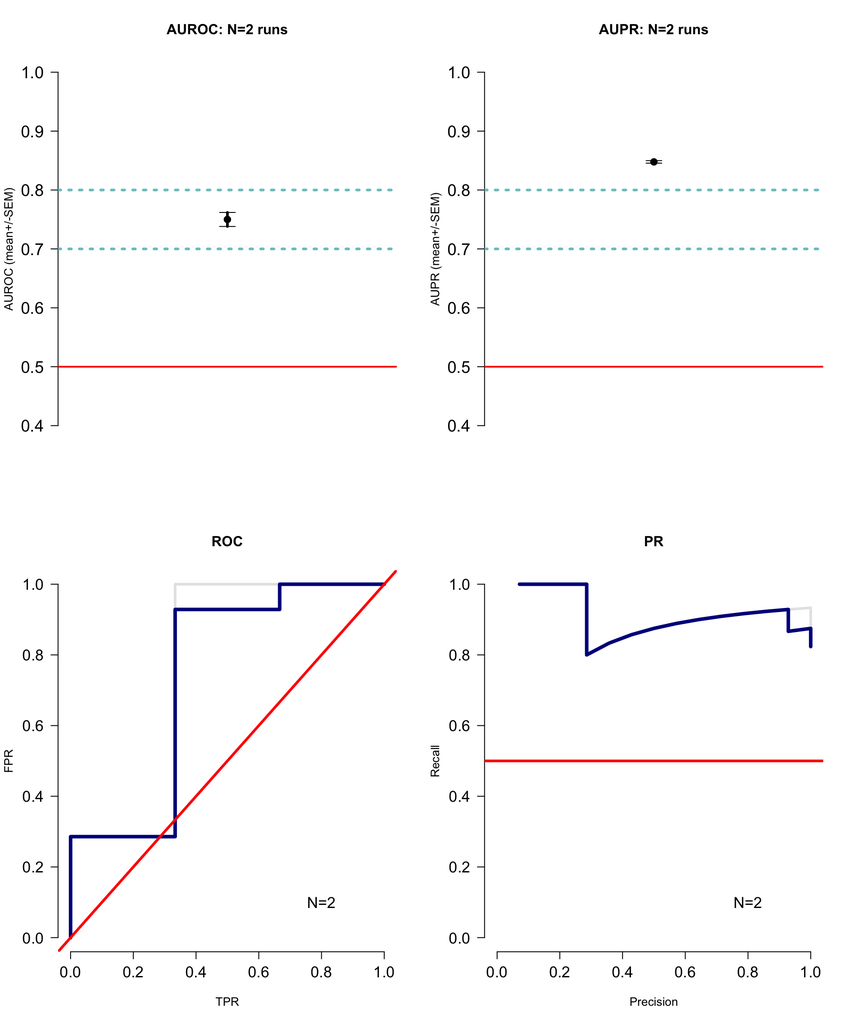

```r
predPerf <- plotPerf(predList, predClasses=st)
```

```r
featScores2 <- lapply(featScores, getNetConsensus)
summary(featScores2)
```

```
##       Length Class      Mode
## EARLY 3      data.frame list
## LATE  3      data.frame list
```

```r
featSelNet <- lapply(featScores2, function(x) {
    callFeatSel(x, fsCutoff=1, fsPctPass=0)
})
print(head(featScores2[["LATE"]]))
```

```
##                                                                                               PATHWAY_NAME
## 1                             1D-_I_MYO__I_-INOSITOL_HEXAKISPHOSPHATE_BIOSYNTHESIS_II__MAMMALIAN__cont.txt
## 2                                                                 3-PHOSPHOINOSITIDE_BIOSYNTHESIS_cont.txt
## 3                                                                  3-PHOSPHOINOSITIDE_DEGRADATION_cont.txt
## 4                                                           ABC_TRANSPORTERS_IN_LIPID_HOMEOSTASIS_cont.txt
## 5                                   ABORTIVE_ELONGATION_OF_HIV-1_TRANSCRIPT_IN_THE_ABSENCE_OF_TAT_cont.txt
## 6 ACTIVATED_PKN1_STIMULATES_TRANSCRIPTION_OF_AR__ANDROGEN_RECEPTOR__REGULATED_GENES_KLK2_AND_KLK3_cont.txt
##   Split1 Split2
## 1      1     NA
## 2      2      2
## 3     NA      2
## 4      1     NA
## 5      1     NA
## 6      2      2
```